# Praktikum 3

Reyzha Siva Dewi

2023-12-17

### Input Data

```r
data <- read.csv("E:/Semester 5/MPDW/NewDelhi_Air_quality.csv")

Yt <- data$AQI
Xt <- data$pm25

dt <-data.frame(Yt, Xt)

str(dt)
```

```
## 'data.frame':    72 obs. of  2 variables:
##  $ Yt: num  30.2 28.2 26.6 25 26 26 26 24 23 24 ...
##  $ Xt: num  5.64 4.62 3.52 2.23 1.98 ...
```

### Pembagian Data

#### Split Data

```r
train <- dt[1:57,]
test <- dt[57:72,]
```

#### Data Time Series

```r
train.ts <- ts(train)
test.ts <- ts(test)
data.ts <- ts(dt)
```

### Model Koyck

```r
model.koyck <- koyckDlm(x = train$Xt, y = train$Yt)
summary(model.koyck)
```

```
##
## Call:
## "Y ~ (Intercept) + Y.1 + X.t"
##
## Residuals:
##      Min       1Q   Median       3Q      Max
## -2.19768 -0.57669 -0.03615  0.58158  2.18318
##
## Coefficients:
##             Estimate Std. Error t value Pr(>|t|)
## (Intercept)  4.54910    1.77579   2.562   0.0133 *
## Y.1          0.87326    0.05731  15.237   <2e-16 ***
## X.t         -0.56825    0.27658  -2.055   0.0449 *
## ---
## Signif. codes:  0 '***' 0.001 '**' 0.01 '*' 0.05 '.' 0.1 ' ' 1
##
## Residual standard error: 0.8986 on 53 degrees of freedom
## Multiple R-Squared: 0.8303,  Adjusted R-squared: 0.8239
## Wald test: 129.9 on 2 and 53 DF,  p-value: < 2.2e-16
##
## Diagnostic tests:
## NULL
##
##                             alpha       beta      phi
## Geometric coefficients:  35.89204 -0.5682546 0.873256
```

```r
AIC(model.koyck)
```

```
## [1] 151.8615
```

```r
BIC(model.koyck)
```

```
## [1] 159.9629
```

### Peramalan dan Akurasi

Berikut adalah hasil peramalan y untuk 16 periode kedepan menggunakan model koyck

```r
fore.koyck <- forecast(model = model.koyck, x=test$Xt, h=16)
fore.koyck
```

```
## $forecasts
##  [1] 25.11328 25.05820 24.86827 24.56956 24.26238 23.96423 23.71988 23.57132
##  [9] 23.51514 23.50870 23.52640 23.54775 23.57057 23.57350 23.55504 23.55832
##
## $call
## forecast.koyckDlm(model = model.koyck, x = test$Xt, h = 16)
##
## attr(,"class")
## [1] "forecast.koyckDlm" "dLagM"
```

```r
mape.koyck <- MAPE(fore.koyck$forecasts, test$Yt)
mape.koyck
```

```
## [1] 0.1326923
```

MAPE yang di dadapatkan bernilai baik, yaitu sebesar 13.27%

#### Akurasi Data Training

```r
mape.koyck.training<-GoF(model.koyck)["MAPE"]
```

#### Akurasi Data Testing

```r
mape.koyck.testing <- MAPE(fore.koyck$forecasts, test$Yt)
c("MAPE Testing"=mape.koyck.testing,"MAPE Training"=mape.koyck.training)
```

```
## $`MAPE Testing`
## [1] 0.1326923
##
## $`MAPE Training.MAPE`
## [1] 0.02495405
```

### Regression with Distributed Lag

#### Pencarian nilai lag optimum

```r
finiteDLMauto(formula = Yt ~ Xt,
              data = data.frame(train),
              model.type = "dlm", error.type = "AIC", trace = FALSE)
```

```
##    q - k   MASE      AIC      BIC    GMRAE   MBRAE R.Adj.Sq    Ljung-Box
## 10    10 1.7918 181.4052 205.4571 69409.72 1.83368  0.50588 4.814509e-08
```

Berdasarkan output tersebut, lag optimum didapatkan ketika lag=10. Selanjutnya dilakukan pemodelan untuk lag=10

#### Pemodelan *Lag* Optimum (lag = 10)

```r
model.dlm <- dlm(x = train$Xt,y = train$Yt, q = 10)
summary(model.dlm)
```

```
##
## Call:
## lm(formula = model.formula, data = design)
##
## Residuals:
##      Min       1Q   Median       3Q      Max
## -2.71041 -0.83916  0.09733  0.83799  2.91674
##
## Coefficients:
##             Estimate Std. Error t value Pr(>|t|)
## (Intercept)   40.971      2.293  17.869  < 2e-16 ***
## x.t          -20.622      6.211  -3.320  0.00211 **
## x.1           13.567     13.579   0.999  0.32458
## x.2            5.848     16.535   0.354  0.72570
## x.3           -1.330     15.861  -0.084  0.93363
## x.4           -2.878     15.189  -0.190  0.85079
## x.5           -4.771     14.732  -0.324  0.74798
## x.6           16.900     12.053   1.402  0.16968
## x.7          -18.277      6.733  -2.714  0.01024 *
## x.8            3.422      4.514   0.758  0.45342
## x.9            6.711      4.327   1.551  0.12987
## x.10          -5.245      2.067  -2.537  0.01579 *
## ---
## Signif. codes:  0 '***' 0.001 '**' 0.01 '*' 0.05 '.' 0.1 ' ' 1
##
## Residual standard error: 1.465 on 35 degrees of freedom
## Multiple R-squared:  0.624,  Adjusted R-squared:  0.5059
## F-statistic: 5.281 on 11 and 35 DF,  p-value: 7.336e-05
##
## AIC and BIC values for the model:
##        AIC      BIC
## 1 181.4052 205.4571
```

```r
AIC(model.dlm)
```

```
## [1] 181.4052
```

```r
BIC(model.dlm)
```

```
## [1] 205.4571
```

Dari hasil tersebut terdapat beberapa peubah yang berpengaruh signifikan terhadap taraf nyata 5% yaitu intercept, $X_t$ , $X_{t-7},X_{t-10}$ <0.05. Hal ini menunjukkan bahwa intercept $X_t$ , $X_{t-7},X_{t-10}$ <0.05 berpengaruh signifikan terhadap y. Adapun model keseluruhan yang terbentuk adalah sebagai berikut

$$\hat{Y_t} = 40.971 - 20.622X_t + 13.567X_{t-1} + 5.848X_{t-2} -
1.330X_{t-3} - 2.878X_{t-4} - 4.771X_{t-5} + 16.900X_{t-6} -
18.277X_{t-7} + 3.422X_{t-8} + 6.711X_{t-9} - 5.245X_{t-10}$$

#### Peramalan dan Akurasi

```r
fore.dlm <- forecast(model = model.dlm, x=test$Xt, h=16)
mape.dlm <- MAPE(fore.dlm$forecasts, test$Yt)
mape.dlm
```

```
## [1] 0.1358914
```

Nilai MAPE DLM yang didapatkan bernilai baik, yaitu sebesar 13.60%

#### Akurasi Data Training

```r
GoF(model.dlm)
```

```
##            n      MAE          MPE       MAPE      sMAPE     MASE      MSE
## model.dlm 47 1.012758 -0.002026638 0.03660523 0.03650655 1.791802 1.597781
##                 MRAE    GMRAE
## model.dlm 6456109988 69409.72
```

Model tersebut merupakan model yang sangat baik dengan nilai MAPE data training (3.66%) yang kurang dari 10%.

### Model Autoregressive

#### Pemodelan

```r
model.ardl <- ardlDlm(x = train$Xt, y = train$Yt, p = 1 , q = 1)

summary(model.ardl)
```

```
##
## Time series regression with "ts" data:
## Start = 2, End = 57
##
## Call:
## dynlm(formula = as.formula(model.text), data = data, start = 1)
##
## Residuals:
##      Min       1Q   Median       3Q      Max
## -2.19437 -0.53377 -0.07398  0.53245  2.18819
##
## Coefficients:
##             Estimate Std. Error t value Pr(>|t|)
## (Intercept)  3.84416    2.00316   1.919   0.0605 .
## X.t         -0.09036    0.79948  -0.113   0.9104
## X.1         -0.31343    0.55520  -0.565   0.5748
## Y.1          0.88721    0.06120  14.496   <2e-16 ***
## ---
## Signif. codes:  0 '***' 0.001 '**' 0.01 '*' 0.05 '.' 0.1 ' ' 1
##
## Residual standard error: 0.9041 on 52 degrees of freedom
## Multiple R-squared:  0.8315, Adjusted R-squared:  0.8218
## F-statistic: 85.52 on 3 and 52 DF,  p-value: < 2.2e-16
```

```r
AIC(model.ardl)
```

```
## [1] 153.478
```

```r
BIC(model.ardl)
```

```
## [1] 163.6048
```

Hasil di atas menunjukkan bahwa $y_{t-1}$ berpengaruh signifikan terhadap $y_t$. Model keseluruhannya adalah sebagai berikut:

$$\hat{Y}= 3.8442 - 0.0904Xt - 0.3134X(t-1) + 0.8872Y(t-1)$$

#### Peramalan dan Akurasi

```r
fore.ardl <- forecast(model = model.ardl, x=test$Xt, h=16)
fore.ardl
```

```
## $forecasts
##  [1] 25.12384 25.20922 25.17747 25.04995 24.85617 24.65393 24.46056 24.30815
##  [9] 24.22036 24.18983 24.18996 24.20387 24.22013 24.23416 24.23389 24.22514
##
## $call
## forecast.ardlDlm(model = model.ardl, x = test$Xt, h = 16)
##
## attr(,"class")
## [1] "forecast.ardlDlm" "dLagM"
```

Data di atas merupakan hasil peramalan untuk 16 periode ke depan menggunakan Model Autoregressive dengan $p=1$ dan $q=1$.

```r
mape.ardl <- MAPE(fore.ardl$forecasts, test$Yt)
mape.ardl
```

```
## [1] 0.1470726
```

Nilai MAPE yang didapatkan terbilang baik, yaitu sebesar 14.70%.

#### Akurasi Data Training

```r
GoF(model.ardl)
```

```
##             n       MAE          MPE       MAPE      sMAPE     MASE       MSE
## model.ardl 56 0.6649318 -0.001022605 0.02471495 0.02467317 1.038956 0.7589879
##                 MRAE    GMRAE
## model.ardl 764716569 13547.56
```

#### *Lag* Optimum

```r
model.ardl.opt <- ardlBoundOrders(data = data.frame(dt), ic = "AIC",

                                  formula = Yt ~ Xt )

min_p=c()

for(i in 1:15){

  min_p[i]=min(model.ardl.opt$Stat.table[[i]])

}

q_opt=which(min_p==min(min_p, na.rm = TRUE))

p_opt=which(model.ardl.opt$Stat.table[[q_opt]] ==

              min(model.ardl.opt$Stat.table[[q_opt]], na.rm = TRUE))

data.frame("q_optimum" = q_opt, "p_optimum" = p_opt,

           "AIC"=model.ardl.opt$min.Stat)
```

```
##   q_optimum p_optimum      AIC
## 1         5        15 124.7089
```

Dari tabel di atas, dapat terlihat bahwa nilai AIC terendah didapat ketika $p=15$ dan $q=5$, yaitu sebesar `124.7089`. Artinya, model autoregressive optimum did$apat ketika p=15 dan $q=5$.

Selanjutnya dapat dilakukan pemodelan dengan nilai $p$ dan $q$ optimum seperti inisialisasi di langkah sebelumnya.

```r
model.ardl2 <- ardlDlm(x = train$Xt, y = train$Yt, p = 15 , q = 5)
summary(model.ardl2)
```

```
##
## Time series regression with "ts" data:
## Start = 16, End = 57
##
## Call:
## dynlm(formula = as.formula(model.text), data = data, start = 1)
##
## Residuals:
##      Min       1Q   Median       3Q      Max
## -0.82795 -0.21807 -0.06184  0.19832  0.95292
##
## Coefficients:
##             Estimate Std. Error t value Pr(>|t|)
## (Intercept)  6.39323    8.42066   0.759   0.4566
## X.t         -9.79936    3.63098  -2.699   0.0138 *
## X.1         12.55109    7.60359   1.651   0.1144
## X.2          2.80197    9.55656   0.293   0.7724
## X.3         -0.03494   10.20593  -0.003   0.9973
## X.4         -8.75652   10.57855  -0.828   0.4176
## X.5          7.05101   10.68081   0.660   0.5167
## X.6         -4.23104   10.02790  -0.422   0.6776
## X.7         -2.27689    9.98750  -0.228   0.8220
## X.8         -0.02309    9.52703  -0.002   0.9981
## X.9          1.79410    8.66257   0.207   0.8380
## X.10         0.55336    7.76096   0.071   0.9439
## X.11        -1.03757    6.05781  -0.171   0.8657
## X.12         1.60399    3.91378   0.410   0.6863
## X.13        -0.35479    2.86667  -0.124   0.9027
## X.14        -1.91046    2.85174  -0.670   0.5106
## X.15         1.61309    1.52639   1.057   0.3032
## Y.1          0.57609    0.23251   2.478   0.0223 *
## Y.2          0.58447    0.26711   2.188   0.0407 *
## Y.3          0.18559    0.26449   0.702   0.4910
## Y.4         -0.21285    0.26613  -0.800   0.4332
## Y.5         -0.33394    0.21453  -1.557   0.1353
## ---
## Signif. codes:  0 '***' 0.001 '**' 0.01 '*' 0.05 '.' 0.1 ' ' 1
##
## Residual standard error: 0.608 on 20 degrees of freedom
## Multiple R-squared:  0.9604, Adjusted R-squared:  0.9187
## F-statistic: 23.07 on 21 and 20 DF,  p-value: 8.9e-10
```

```r
AIC(model.ardl2)
```

```
## [1] 92.22958
```

```r
BIC(model.ardl2)
```

```
## [1] 132.196
```

Hasil di atas menunjukkan bahwa $X_t$ , $Y_{t-1}$ , dan $Y_{t-2}$ berpengaruh signifikan terhadap $y_t$. Model keseluruhannya adalah sebagai berikut

$$\hat{Y} = 6.3923 - 9.7994X_t + 12.5511X_{t-1} + 2.8020X_{t-2} -
0.0349X_{t-3} - 8.7565X_{t-4} +7.0510X_{t-5} - 4.2310X_{t-6} -
2.2769X_{t-7} - 0.0231X_{t-8} + 1.7941X_{t-9} + 0.5534X_{t-10} -
1.0376X_{t-11} + 1.6040X_{t-12} - 0.3548X_{t-13} - 1.9105X_{t-14} +
1.6131X_{t-15} + 0.5761Y_{t-1} + 0.5845Y_{t-2} + 0.1856Y_{t-3} -
0.2129Y_{t-4} - 0.3340Y_{t-5}$$

### Perbandingan Model

```r
akurasi <- matrix(c(mape.koyck, mape.dlm, mape.ardl))

row.names(akurasi)<- c("Koyck","DLM","Autoregressive")

colnames(akurasi) <- c("MAPE")

akurasi
```

```
##                     MAPE
## Koyck          0.1326923
## DLM            0.1358914
## Autoregressive 0.1470726
```

Berdasarkan nilai MAPE, model paling optimum didapat pada Model Koyck karena memiliki nilai MAPE yang terkecil, yaitu sebesar 0.1326923, bila dibanding dengan DLM (0.1358914) dan Autoregressive (0.1470726).

### Plot

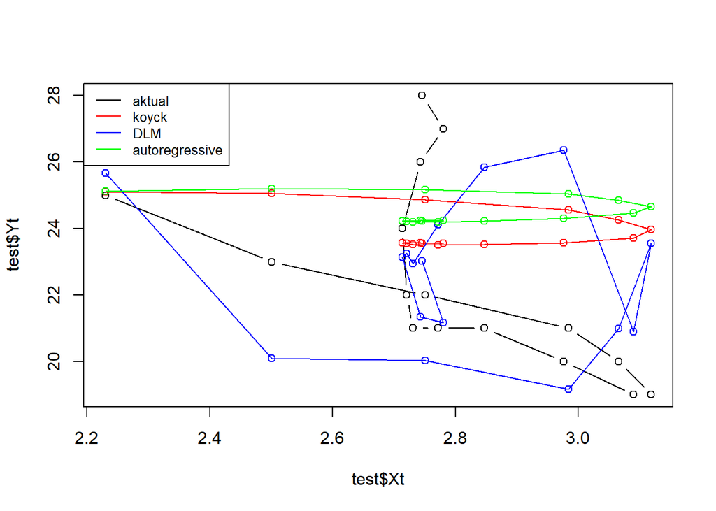

```r
par(mfrow=c(1,1))

plot(test$Xt, test$Yt, type="b", col="black")
points(test$Xt, fore.koyck$forecasts,col="red")
lines(test$Xt, fore.koyck$forecasts,col="red")
points(test$Xt, fore.dlm$forecasts,col="blue")
lines(test$Xt, fore.dlm$forecasts,col="blue")
points(test$Xt, fore.ardl$forecasts,col="green")
lines(test$Xt, fore.ardl$forecasts,col="green")
legend("topleft",c("aktual", "koyck","DLM ", "autoregressive"), lty=1, col=c("black","red","blue","green"), cex=0.8)
```

Berdasarkan plot tersebut, terlihat bahwa plot yang paling mendekati data aktualnya adalah Model DLM bila dibandingkan dengan plot Autoregressive dan Koyck. Namun, bila dilihat dari nilai MAPE terkecilnya adalah model koyck sehingga dapat disimpulkan model regresi terbaiknya adalah Koyck.